# SN-Project-B-Group-3

### Block Model for 2015

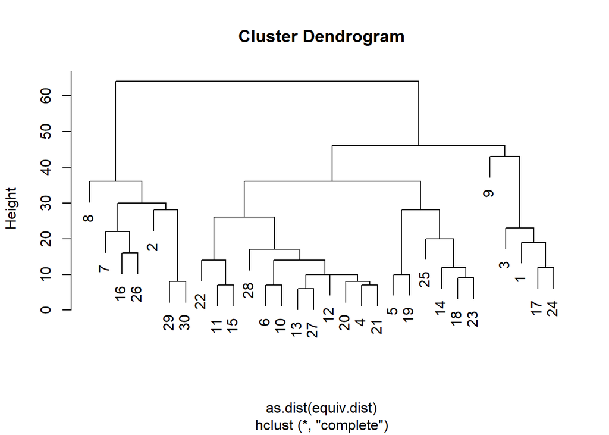

```r
# Plot the cluster dendrogram
eq_2015 <-equiv.clust(list(collab_2015,t(collab_2015),trust_2015,t(trust_2015)), mode="digraph")
eq_2015 <-equiv.clust(list(collab_2015,trust_2015), mode="digraph")
plot(eq_2015)
```

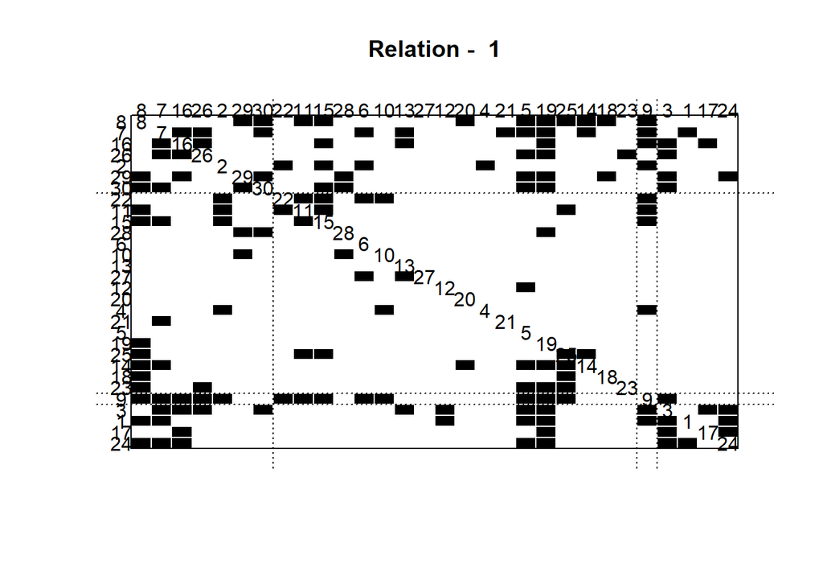

```r
#Block model: 2015
c_2015<-blockmodel(collab_2015,eq_2015,k=4)
plot(c_2015)
```

```r
bimage_2015 <- c_2015$block.model
bimage_2015
```

```
##           Block 1   Block 2    Block 3   Block 4
## Block 1 0.6666667 0.3571429 0.13888889 0.5000000
## Block 2 0.2500000 0.3571429 0.25396825 0.5714286
## Block 3 0.0000000 0.1428571 0.08169935 0.2222222
## Block 4 0.2500000 0.7142857 0.44444444       NaN
```

```r
bimage_2015[bimage_2015 < 0.5] <- 0
bimage_2015
```

```
##           Block 1   Block 2 Block 3   Block 4
## Block 1 0.6666667 0.0000000       0 0.5000000
## Block 2 0.0000000 0.0000000       0 0.5714286
## Block 3 0.0000000 0.0000000       0 0.0000000
## Block 4 0.0000000 0.7142857       0       NaN
```

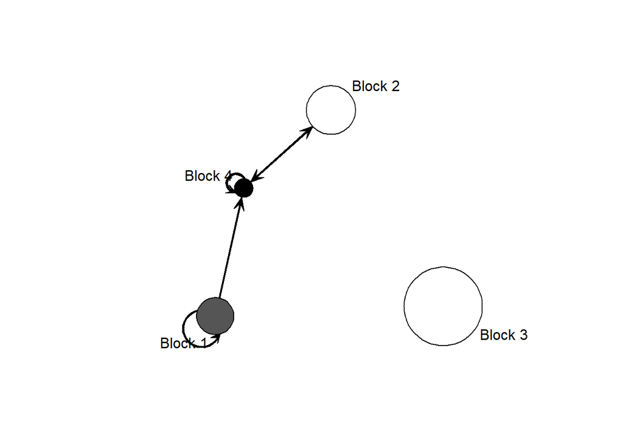

```r
bimage_2015[is.nan(bimage_2015)] <- 1

gplot(bimage_2015, diag=TRUE,
      edge.lwd=bimage_2015*2.5,
      label=colnames(bimage_2015),
      vertex.cex=sqrt(table(c_2015$block.membership))/.75,
      gmode="digraph", vertex.sides=50,
      vertex.col=gray(1-diag(bimage_2015)))
```

Finding for blcok model of 2015:

- From the result of the block model generated from 2015 social network dataset, four blocks are generalized from the contack network.
- Among four blocks, block 3 is the largest, however there is no interaction between block 3 and the rest of the blocks.
- For block 2, block a, block 4, connection are obvious among the three nodes.
- It is also worth noticing that Block 4, though the smallest, receives the most contact from nodes in Block 1 and Block 2.

### Block Model for 2016

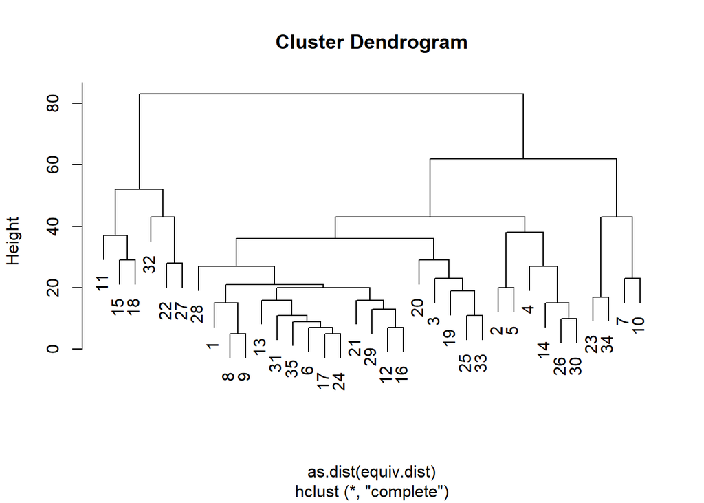

```r
eq_2016 <-equiv.clust(list(collab_2016,t(collab_2016),trust_2016,t(trust_2016)), mode="digraph")
eq_2016 <-equiv.clust(list(collab_2016,trust_2016), mode="digraph")
plot(eq_2016)
```

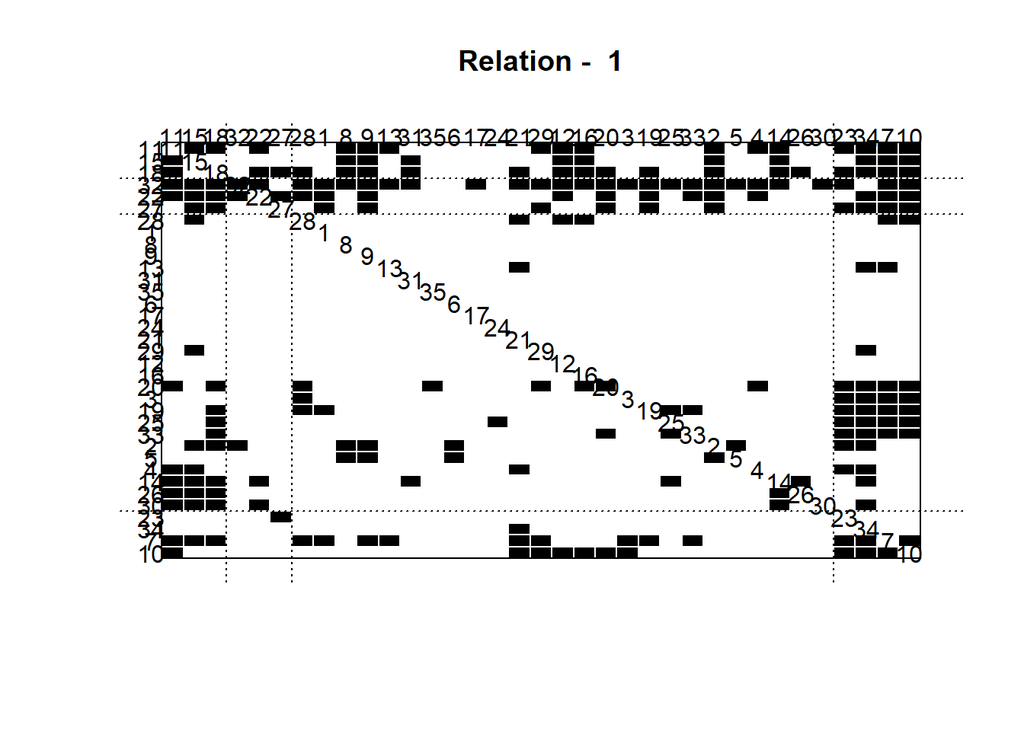

```r
c_2016<-blockmodel(collab_2016,eq_2016,k=4)
plot(c_2016)
```

```r
bimage_2016 <- c_2016$block.model
bimage_2016
```

```
##            Block 1   Block 2   Block 3    Block 4
## Block 1 0.05166667 0.3100000 0.2666667 0.04000000
## Block 2 0.16000000 0.5000000 0.3333333 0.08333333
## Block 3 0.37333333 0.9166667 0.6666667 0.33333333
## Block 4 0.48000000 0.8333333 0.8888889 0.50000000
```

```r
bimage_2016[bimage_2016 < 0.5] <- 0
bimage_2016
```

```
##         Block 1   Block 2   Block 3 Block 4
## Block 1       0 0.0000000 0.0000000     0.0
## Block 2       0 0.5000000 0.0000000     0.0
## Block 3       0 0.9166667 0.6666667     0.0
## Block 4       0 0.8333333 0.8888889     0.5
```

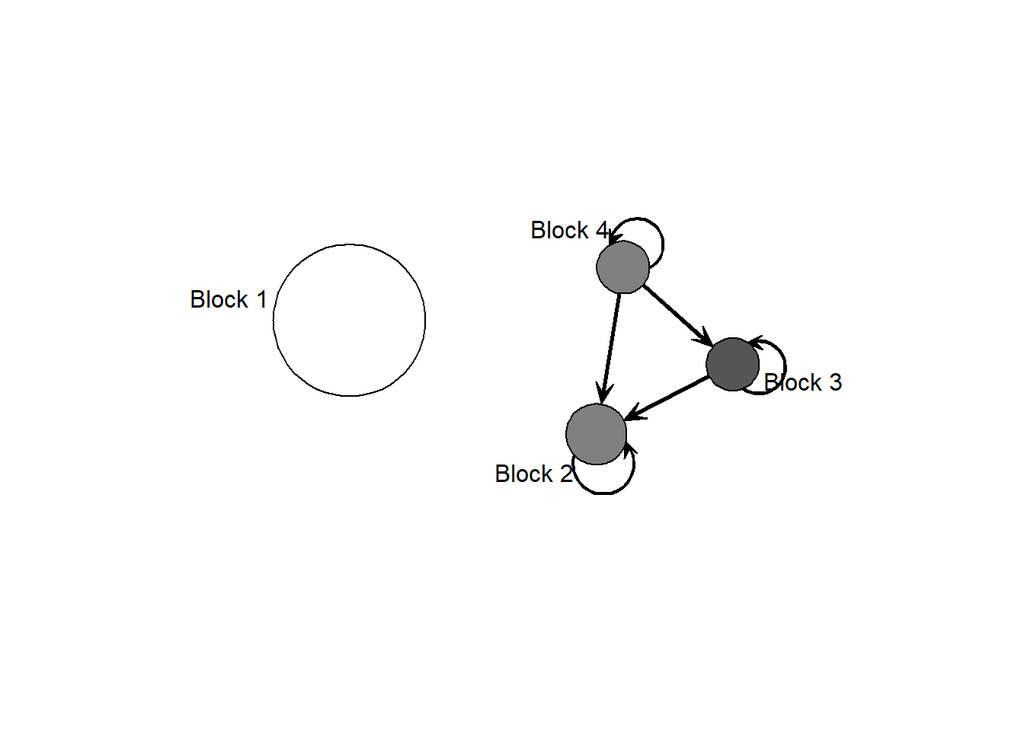

```r
bimage_2016[is.nan(bimage_2016)] <- 1

gplot(bimage_2016, diag=TRUE,
      edge.lwd=bimage_2016*2.5,
      label=colnames(bimage_2016),
      vertex.cex=sqrt(table(c_2016$block.membership))/.75,
      gmode="digraph", vertex.sides=50,
      vertex.col=gray(1-diag(bimage_2016)))
```

Findings for block model of 2016:

- From the result of the block model, four blocks are generalized from the contack network.
- Among four blocks, block 1 is the largest, however there is no interaction between block 1 and the rest of the blocks.
- For block 2, block 3, block 4, connection are obvious among the three nodes. And it is also worth noticing that Block 2 receives the most contact from nodes in Block 3 and Block 4.